# Praktikum 2

Ibnu Yazid M0401241072

2026-08-27

```r
library(dplyr)
library(TTR)
library(forecast)
library(lmtest) #digunakan untuk uji formal pendeteksian autokorelasi
library(orcutt) #untuk membuat model regresi Cochrane-Orcutt
library(HoRM) #untuk membuat model regresi Hildreth-Lu
```

## Nomor 1

```r
period1 <- 1:20
market_share <- c(3.63, 4.20, 3.33, 4.54, 2.89, 4.87, 4.90, 5.29, 6.18, 7.20,
                  7.25, 6.09, 6.80, 8.65, 8.43, 8.29, 7.18, 7.90, 8.45, 8.23)
price <- c(0.97, 0.95, 0.99, 0.91, 0.98, 0.90, 0.89, 0.86, 0.85, 0.82,
           0.79, 0.83, 0.81, 0.77, 0.76, 0.80, 0.83, 0.79, 0.76, 0.78)

dtData1 <- data.frame(Period = period1, MarketShare = market_share, Price = price)
dtData1
```

```
##    Period MarketShare Price
## 1       1        3.63  0.97
## 2       2        4.20  0.95
## 3       3        3.33  0.99
## 4       4        4.54  0.91
## 5       5        2.89  0.98
## 6       6        4.87  0.90
## 7       7        4.90  0.89
## 8       8        5.29  0.86
## 9       9        6.18  0.85
## 10     10        7.20  0.82
## 11     11        7.25  0.79
## 12     12        6.09  0.83
## 13     13        6.80  0.81
## 14     14        8.65  0.77
## 15     15        8.43  0.76
## 16     16        8.29  0.80
## 17     17        7.18  0.83
## 18     18        7.90  0.79
## 19     19        8.45  0.76
## 20     20        8.23  0.78
```

```r
data.ts <- ts(dtData1$MarketShare)
data.ts
```

```
## Time Series:
## Start = 1
## End = 20
## Frequency = 1
##  [1] 3.63 4.20 3.33 4.54 2.89 4.87 4.90 5.29 6.18 7.20 7.25 6.09 6.80 8.65 8.43
## [16] 8.29 7.18 7.90 8.45 8.23
```

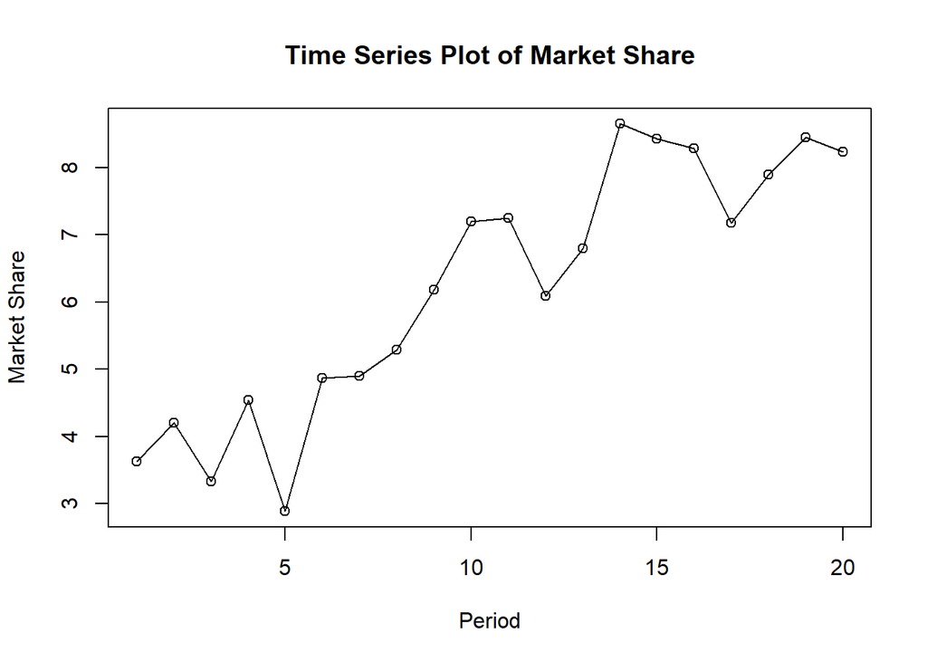

```r
ts.plot(data.ts, xlab="Period", ylab="Market Share", main="Time Series Plot of Market Share")
points(data.ts)
```

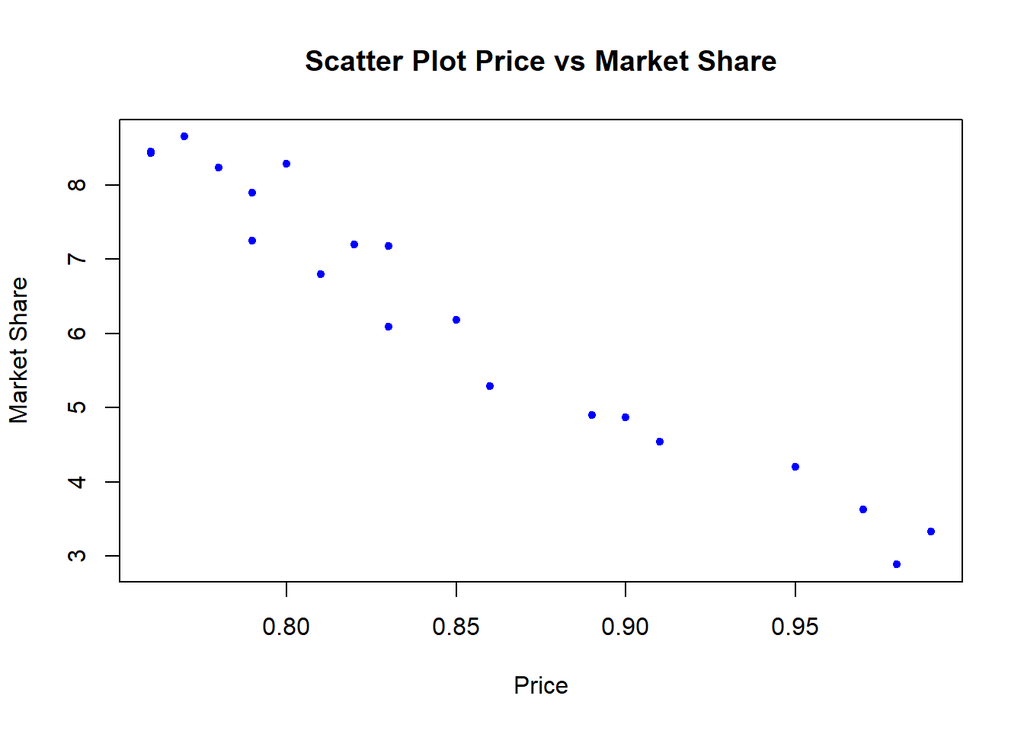

```r
plot(dtData1$Price, dtData1$MarketShare, pch = 20, col = "blue",
     main = "Scatter Plot Price vs Market Share",
     xlab = "Price",
     ylab = "Market Share")
```

```r
cor(dtData1$Price, dtData1$MarketShare)
```

```
## [1] -0.9752564
```

```r
model <- lm(MarketShare ~ Price, data = dtData1)
summary(model)
```

```
##
## Call:
## lm(formula = MarketShare ~ Price, data = dtData1)
##
## Residuals:
##      Min       1Q   Median       3Q      Max
## -0.73068 -0.29764 -0.00966  0.30224  0.81193
##
## Coefficients:
##             Estimate Std. Error t value Pr(>|t|)
## (Intercept)   26.910      1.110   24.25 3.39e-15 ***
## Price        -24.290      1.298  -18.72 3.02e-13 ***
## ---
## Signif. codes:  0 '***' 0.001 '**' 0.01 '*' 0.05 '.' 0.1 ' ' 1
##
## Residual standard error: 0.4287 on 18 degrees of freedom
## Multiple R-squared:  0.9511, Adjusted R-squared:  0.9484
## F-statistic: 350.3 on 1 and 18 DF,  p-value: 3.019e-13
```

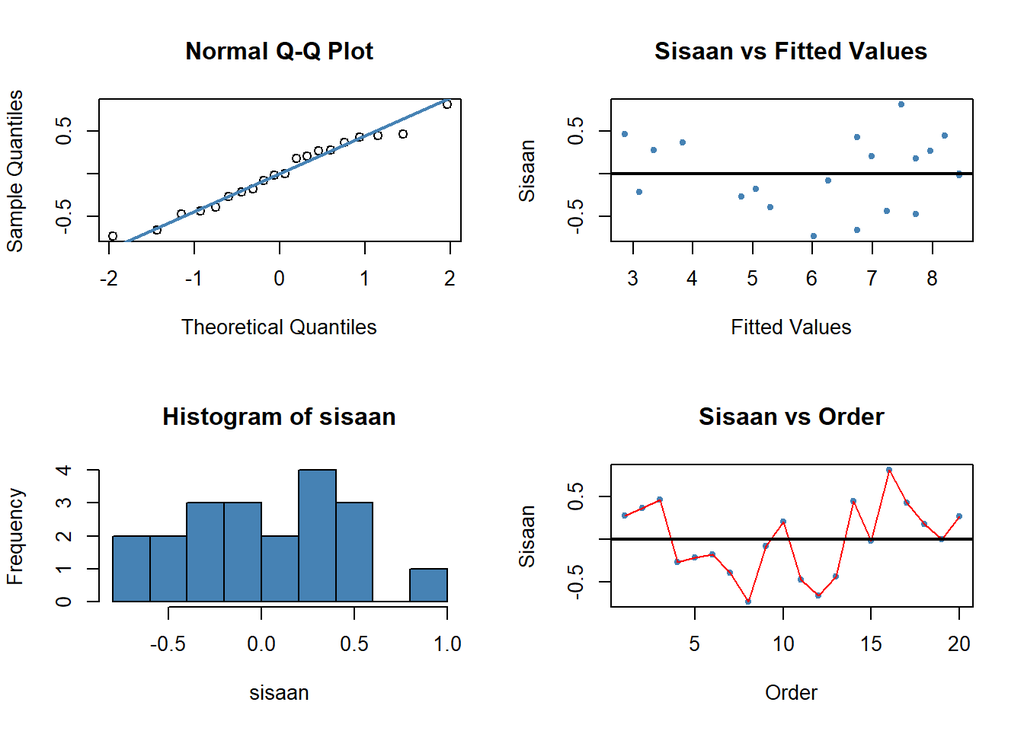

```r
sisaan <- residuals(model)
fitValue <- predict(model)

par(mfrow = c(2,2))
qqnorm(sisaan)
qqline(sisaan, col = "steelblue", lwd = 2)
plot(fitValue, sisaan, col = "steelblue", pch = 20, xlab = "Fitted Values", ylab = "Sisaan", main = "Sisaan vs Fitted Values")
abline(a = 0, b = 0, lwd = 2)
hist(sisaan, col = "steelblue")
plot(seq(1,20,1), sisaan, col = "steelblue", pch = 20, xlab = "Order", ylab = "Sisaan", main = "Sisaan vs Order")
lines(seq(1,20,1), sisaan, col = "red")
abline(a = 0, b = 0, lwd = 2)
```

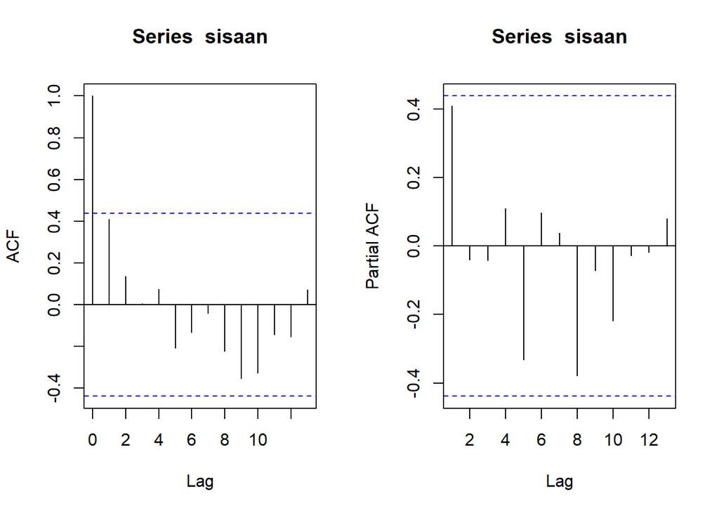

```r
par(mfrow = c(1,2))
acf(sisaan)
pacf(sisaan)
```

```r
dwtest(model)
```

```
##
##  Durbin-Watson test
##
## data:  model
## DW = 1.1358, p-value = 0.009813
## alternative hypothesis: true autocorrelation is greater than 0
```

```r
modelCO <- cochrane.orcutt(model)
modelCO
```

```
## Cochrane-orcutt estimation for first order autocorrelation
##
## Call:
## lm(formula = MarketShare ~ Price, data = dtData1)
##
##  number of interaction: 8
##  rho 0.425232
##
## Durbin-Watson statistic
## (original):    1.13582 , p-value: 9.813e-03
## (transformed): 1.95804 , p-value: 4.151e-01
##
##  coefficients:
## (Intercept)       Price
##    26.72209   -24.08413
```

```r
rho <- modelCO$rho
rho
```

```
## [1] 0.4252321
```

```r
y.trans <- dtData1$MarketShare[-1] - dtData1$MarketShare[-20] * rho
x.trans <- dtData1$Price[-1] - dtData1$Price[-20] * rho
modelCOmanual <- lm(y.trans ~ x.trans)

b0bintang <- modelCOmanual$coefficients[1]
b0 <- b0bintang / (1 - rho)
b1 <- modelCOmanual$coefficients[2]
b0
```

```
## (Intercept)
##    26.72209
```

```r
b1
```

```
##   x.trans
## -24.08413
```

```r
hildreth.lu.func <- function(r, model){
  x <- model.matrix(model)[,-1]
  y <- model.response(model.frame(model))
  n <- length(y)
  t <- 2:n
  y <- y[t] - r * y[t-1]
  x <- x[t] - r * x[t-1]
  return(lm(y ~ x))
}

rOpt <- seq(0.1, 0.9, by = 0.001)
tabOpt <- data.frame("rho" = rOpt, "SSE" = sapply(rOpt, function(i){deviance(hildreth.lu.func(i, model))}))
rho_best <- tabOpt[which.min(tabOpt$SSE), "rho"]
rho_best
```

```
## [1] 0.425
```

```r
modelHL <- hildreth.lu.func(rho_best, model)
summary(modelHL)
```

```
##
## Call:
## lm(formula = y ~ x)
##
## Residuals:
##      Min       1Q   Median       3Q      Max
## -0.55517 -0.25066 -0.05505  0.25010  0.83017
##
## Coefficients:
##             Estimate Std. Error t value Pr(>|t|)
## (Intercept)  15.3655     0.9387   16.37 7.68e-12 ***
## x           -24.0848     1.9380  -12.43 5.88e-10 ***
## ---
## Signif. codes:  0 '***' 0.001 '**' 0.01 '*' 0.05 '.' 0.1 ' ' 1
##
## Residual standard error: 0.3955 on 17 degrees of freedom
## Multiple R-squared:  0.9008, Adjusted R-squared:  0.895
## F-statistic: 154.4 on 1 and 17 DF,  p-value: 5.88e-10
```

```r
dwtest(modelHL)
```

```
##
##  Durbin-Watson test
##
## data:  modelHL
## DW = 1.9577, p-value = 0.4148
## alternative hypothesis: true autocorrelation is greater than 0
```

```r
sseModelawal <- anova(model)$`Sum Sq`[2]
sseModelCO <- deviance(modelCOmanual)
sseModelHL <- deviance(modelHL)

mseModelawal <- sseModelawal / length(dtData1$MarketShare)
mseModelCO <- sseModelCO / length(dtData1$MarketShare)
mseModelHL <- sseModelHL / length(dtData1$MarketShare)

akurasi <- matrix(c(sseModelawal, sseModelCO, sseModelHL,
                    mseModelawal, mseModelCO, mseModelHL), nrow=2, ncol=3, byrow = T)
colnames(akurasi) <- c("Model Awal", "Cochrane-Orcutt", "Hildreth-Lu")
row.names(akurasi) <- c("SSE", "MSE")
akurasi
```

```
##     Model Awal Cochrane-Orcutt Hildreth-Lu
## SSE  3.3082574       2.6593681   2.6593683
## MSE  0.1654129       0.1329684   0.1329684
```

## Nomor 2

```r
tahun_sales <- 1975:2014
data_sales <- c(11.7, 12.0, 12.3, 12.8, 13.1, 13.6, 13.9, 14.4, 14.7, 15.3,
                 15.5, 15.8, 16.1, 16.6, 16.9, 16.7, 16.9, 17.4, 17.6, 17.9,
                 18.0, 17.9, 18.0, 18.2, 18.2, 18.3, 18.6, 19.2, 19.3, 19.5,
                 19.2, 19.3, 19.5, 20.0, 20.0, 19.9, 19.8, 19.9, 20.2, 21.0)
data_adv <- c(9.4, 9.6, 10, 10.4, 10.8, 10.9, 11.7, 12.2, 12.5, 12.9,
               13.0, 13.2, 13.8, 14.2, 14.6, 14.4, 15.0, 15.4, 15.7, 15.9,
               15.9, 16.0, 16.3, 16.2, 16.8, 17.3, 17.6, 18.1, 18.3, 18.5,
               18.7, 18.9, 19.2, 20.0, 20.0, 20.3, 20.4, 21.0, 21.5, 22.1)

dtSales <- data.frame(Tahun = tahun_sales, Sales = data_sales, Advertising = data_adv)
dtSales
```

```
##    Tahun Sales Advertising
## 1   1975  11.7         9.4
## 2   1976  12.0         9.6
## 3   1977  12.3        10.0
## 4   1978  12.8        10.4
## 5   1979  13.1        10.8
## 6   1980  13.6        10.9
## 7   1981  13.9        11.7
## 8   1982  14.4        12.2
## 9   1983  14.7        12.5
## 10  1984  15.3        12.9
## 11  1985  15.5        13.0
## 12  1986  15.8        13.2
## 13  1987  16.1        13.8
## 14  1988  16.6        14.2
```

[output cut: 26 more lines]

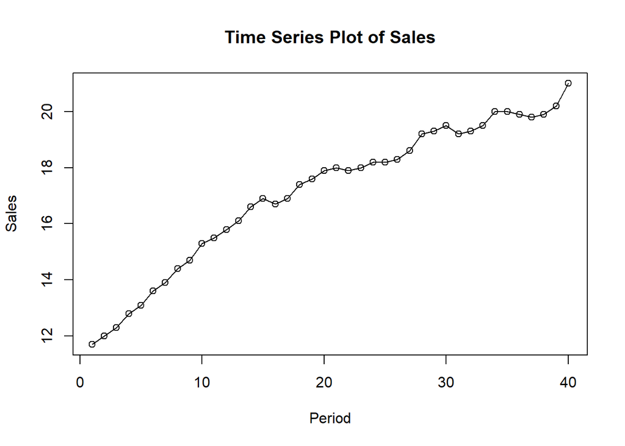

```r
sales.ts <- ts(dtSales$Sales)

ts.plot(sales.ts, xlab="Period", ylab="Sales", main="Time Series Plot of Sales")
points(sales.ts)
```

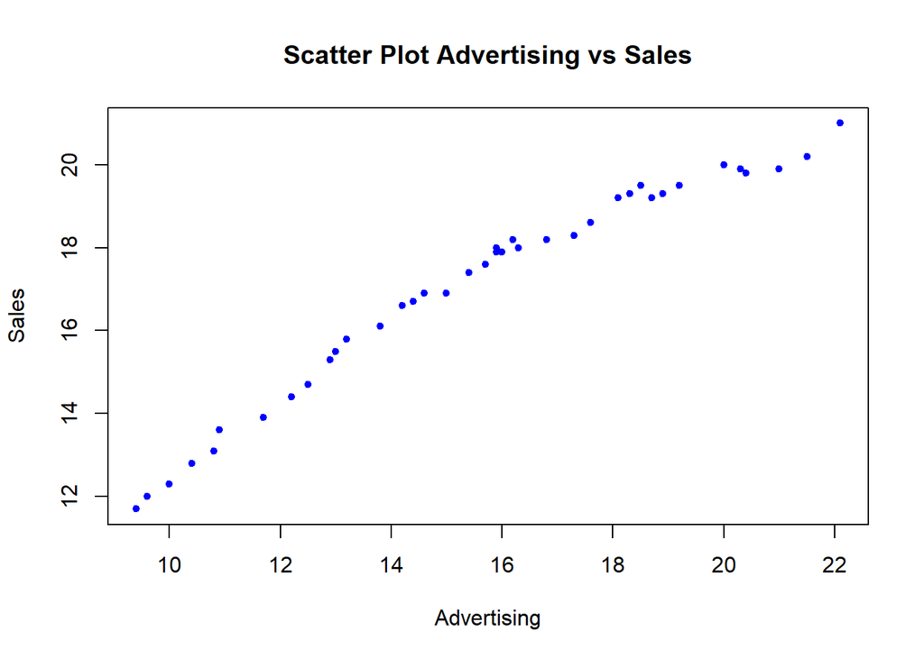

```r
plot(dtSales$Advertising, dtSales$Sales, pch = 20, col = "blue",
     main = "Scatter Plot Advertising vs Sales",
     xlab = "Advertising",
     ylab = "Sales")
```

```r
cor(dtSales$Advertising, dtSales$Sales)
```

```
## [1] 0.9795849
```

```r
model_sales <- lm(Sales ~ Advertising, data = dtSales)
summary(model_sales)
```

```
##
## Call:
## lm(formula = Sales ~ Advertising, data = dtSales)
##
## Residuals:
##      Min       1Q   Median       3Q      Max
## -1.03758 -0.40343  0.08933  0.45674  0.74036
##
## Coefficients:
##             Estimate Std. Error t value Pr(>|t|)
## (Intercept)  5.96513    0.38092   15.66   <2e-16 ***
## Advertising  0.71035    0.02365   30.04   <2e-16 ***
## ---
## Signif. codes:  0 '***' 0.001 '**' 0.01 '*' 0.05 '.' 0.1 ' ' 1
##
## Residual standard error: 0.527 on 38 degrees of freedom
## Multiple R-squared:  0.9596, Adjusted R-squared:  0.9585
## F-statistic: 902.3 on 1 and 38 DF,  p-value: < 2.2e-16
```

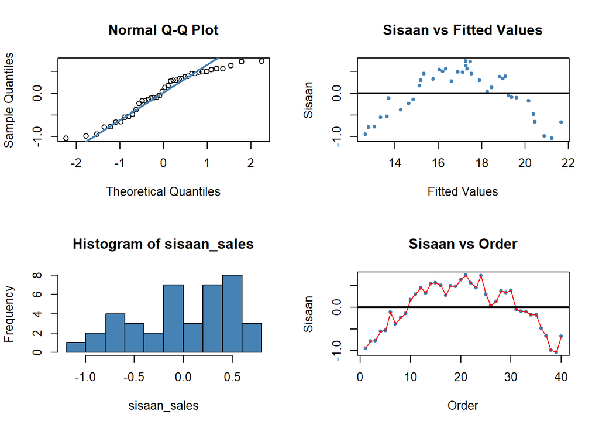

```r
sisaan_sales <- residuals(model_sales)
fit_sales <- predict(model_sales)

par(mfrow = c(2,2))
qqnorm(sisaan_sales)
qqline(sisaan_sales, col = "steelblue", lwd = 2)
plot(fit_sales, sisaan_sales, col = "steelblue", pch = 20, xlab = "Fitted Values", ylab = "Sisaan", main = "Sisaan vs Fitted Values")
abline(a = 0, b = 0, lwd = 2)
hist(sisaan_sales, col = "steelblue")
plot(seq(1, length(sisaan_sales), 1), sisaan_sales, col = "steelblue", pch = 20, xlab = "Order", ylab = "Sisaan", main = "Sisaan vs Order")
lines(seq(1, length(sisaan_sales), 1), sisaan_sales, col = "red")
abline(a = 0, b = 0, lwd = 2)
```

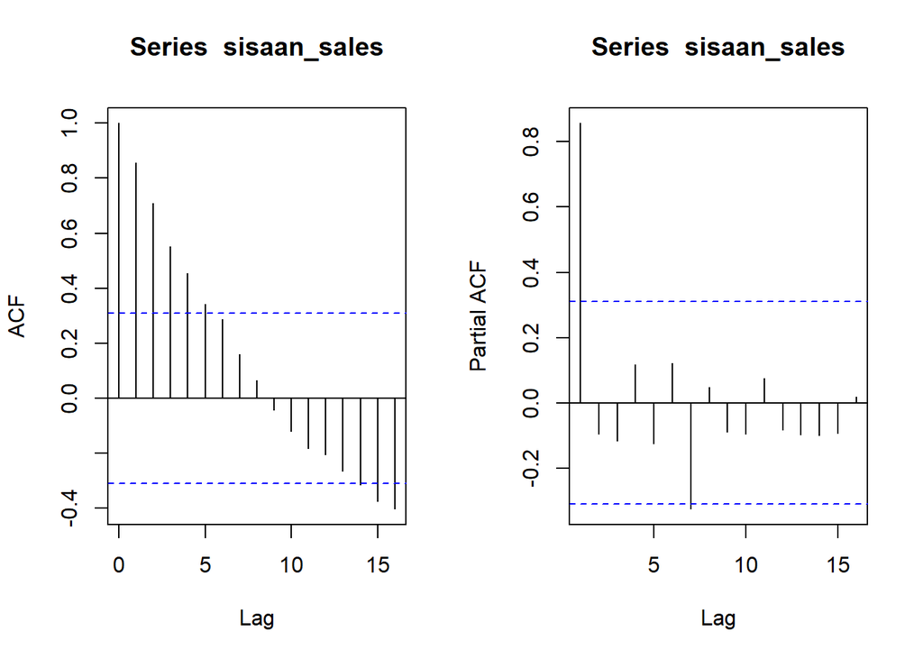

```r
par(mfrow = c(1,2))
acf(sisaan_sales)
pacf(sisaan_sales)
```

```r
dwtest(model_sales)
```

```
##
##  Durbin-Watson test
##
## data:  model_sales
## DW = 0.16204, p-value < 2.2e-16
## alternative hypothesis: true autocorrelation is greater than 0
```

```r
modelCO_sales <- cochrane.orcutt(model_sales)
modelCO_sales
```

```
## Cochrane-orcutt estimation for first order autocorrelation
##
## Call:
## lm(formula = Sales ~ Advertising, data = dtSales)
##
##  number of interaction: 39
##  rho 0.903123
##
## Durbin-Watson statistic
## (original):    0.16204 , p-value: 8.935e-20
## (transformed): 1.93925 , p-value: 3.78e-01
##
##  coefficients:
## (Intercept) Advertising
##   10.252375    0.488489
```

```r
rho_sales_co <- modelCO_sales$rho
rho_sales_co
```

```
## [1] 0.9031233
```

```r
sales.trans <- dtSales$Sales[-1] - dtSales$Sales[-length(dtSales$Sales)] * rho_sales_co
adv.trans <- dtSales$Advertising[-1] - dtSales$Advertising[-length(dtSales$Advertising)] * rho_sales_co

modelCOmanual_sales <- lm(sales.trans ~ adv.trans)
summary(modelCOmanual_sales)
```

```
##
## Call:
## lm(formula = sales.trans ~ adv.trans)
##
## Residuals:
##      Min       1Q   Median       3Q      Max
## -0.37730 -0.14957  0.01257  0.10464  0.45315
##
## Coefficients:
##             Estimate Std. Error t value Pr(>|t|)
## (Intercept)  0.99322    0.14141   7.023 2.64e-08 ***
## adv.trans    0.48849    0.07543   6.476 1.43e-07 ***
## ---
## Signif. codes:  0 '***' 0.001 '**' 0.01 '*' 0.05 '.' 0.1 ' ' 1
##
## Residual standard error: 0.1868 on 37 degrees of freedom
## Multiple R-squared:  0.5313, Adjusted R-squared:  0.5186
## F-statistic: 41.94 on 1 and 37 DF,  p-value: 1.426e-07
```

```r
b0_sales_co <- modelCOmanual_sales$coefficients[1] / (1 - rho_sales_co)
b1_sales_co <- modelCOmanual_sales$coefficients[2]
b0_sales_co
```

```
## (Intercept)
##    10.25237
```

```r
b1_sales_co
```

```
## adv.trans
## 0.4884891
```

```r
hildreth.lu.func <- function(r, model){
  x <- model.matrix(model)[,-1]
  y <- model.response(model.frame(model))
  n <- length(y)
  t <- 2:n
  y <- y[t] - r * y[t-1]
  x <- x[t] - r * x[t-1]
  return(lm(y ~ x))
}

rOpt_sales <- seq(0.1, 0.9, by = 0.001)
tabOpt_sales <- data.frame("rho" = rOpt_sales, "SSE" = sapply(rOpt_sales, function(i){deviance(hildreth.lu.func(i, model_sales))}))

rho_opt_sales <- tabOpt_sales[which.min(tabOpt_sales$SSE), "rho"]
rho_opt_sales
```

```
## [1] 0.9
```

```r
modelHL_sales <- hildreth.lu.func(rho_opt_sales, model_sales)
summary(modelHL_sales)
```

```
##
## Call:
## lm(formula = y ~ x)
##
## Residuals:
##     Min      1Q  Median      3Q     Max
## -0.3749 -0.1461  0.0148  0.1057  0.4496
##
## Coefficients:
##             Estimate Std. Error t value Pr(>|t|)
## (Intercept)  1.01310    0.14198   7.135 1.87e-08 ***
## x            0.49358    0.07379   6.689 7.38e-08 ***
## ---
## Signif. codes:  0 '***' 0.001 '**' 0.01 '*' 0.05 '.' 0.1 ' ' 1
##
## Residual standard error: 0.1868 on 37 degrees of freedom
## Multiple R-squared:  0.5474, Adjusted R-squared:  0.5351
## F-statistic: 44.74 on 1 and 37 DF,  p-value: 7.382e-08
```

```r
dwtest(modelHL_sales)
```

```
##
##  Durbin-Watson test
##
## data:  modelHL_sales
## DW = 1.9402, p-value = 0.3782
## alternative hypothesis: true autocorrelation is greater than 0
```

```r
sse_awal_sales <- deviance(model_sales)
sse_co_sales   <- deviance(modelCOmanual_sales)
sse_hl_sales   <- deviance(modelHL_sales)

n_sales <- nrow(dtSales)
mse_awal_sales <- sse_awal_sales / n_sales
mse_co_sales   <- sse_co_sales / n_sales
mse_hl_sales   <- sse_hl_sales / n_sales

akurasi_sales <- matrix(c(sse_awal_sales, sse_co_sales, sse_hl_sales,
                          mse_awal_sales, mse_co_sales, mse_hl_sales),
                        nrow = 2, ncol = 3, byrow = TRUE)

colnames(akurasi_sales) <- c("Model Awal", "Cochrane-Orcutt", "Hildreth-Lu")
row.names(akurasi_sales) <- c("SSE", "MSE")
akurasi_sales
```

```
##     Model Awal Cochrane-Orcutt Hildreth-Lu
## SSE 10.5545322      1.29122545  1.29139494
## MSE  0.2638633      0.03228064  0.03228487
```

## Kesimpulan

Berdasarkan analisis regresi deret waktu pada Data 1 (Market Share vs Price), model regresi awal terdeteksi mengalami masalah autokorelasi positif berdasarkan uji Durbin-Watson dengan statistik DW = 1.1358 dan p-value = 0.009813 (kurang dari 0.05). Setelah dilakukan penanganan menggunakan metode Cochrane-Orcutt dan Hildreth-Lu, masalah autokorelasi berhasil diatasi yang ditunjukkan oleh peningkatan nilai statistik DW menjadi 1.9577 dengan p-value = 0.4148 (lebih besar dari 0.05). Kedua metode penanganan menghasilkan performa yang sepadan dan terbukti jauh lebih baik dibanding model awal, dengan penurunan nilai SSE dari 3.3082574 menjadi sekitar 2.659368 dan MSE dari 0.1654129 menjadi 0.1329684.

Sementara itu, pada Data 2 (Sales vs Advertising), model regresi awal juga terdeteksi mengalami autokorelasi positif yang sangat signifikan dengan statistik DW = 0.16204 dan p-value kurang dari 2.2e-16. Penanganan autokorelasi dengan metode Hildreth-Lu berhasil memulihkan asumsi kebebasan sisaan, ditandai dengan nilai statistik DW yang meningkat tajam menjadi 1.9402 dan p-value = 0.3782. Secara keseluruhan, metode Cochrane-Orcutt dan Hildreth-Lu mampu meningkatkan presisi pemodelan Data 2 secara drastis, menurunkan nilai SSE dari 10.5545322 menjadi sekitar 1.2912254 (Cochrane-Orcutt) dan 1.2913949 (Hildreth-Lu), serta memangkas nilai MSE dari 0.2638633 menjadi sekitar 0.03228.